```r
#load required packages

library(quantvoe)
library(tidyverse)
```

```r
library(ggplot2)
library(cowplot)
theme_set(theme_cowplot())
```

In this example you will compute vibration of effects for two synthetic datasets built from NHANES (https://www.cdc.gov/nchs/nhanes/index.htm) data.

```r
#explore vignette data after loading quantvoe package

print('Number of independent variables:')
```

```
## [1] "Number of independent variables:"
```

```r
ncol(quantvoe::independent_toy_dataset1_nhanes)-1
```

```
## [1] 342
```

```r
print('Number of dependent variables:')
```

```
## [1] "Number of dependent variables:"
```

```r
ncol(quantvoe::dependent_toy_dataset1_nhanes)-1
```

```
## [1] 2
```

```r
print('Identity of dependent variables:')
```

```
## [1] "Identity of dependent variables:"
```

```r
colnames(dependent_toy_dataset1_nhanes)[2:3]
```

```
## [1] "MSYS"   "BMXBMI"
```

```r
head(quantvoe::dependent_toy_dataset1_nhanes)
```

```
##   sampleID     MSYS BMXBMI
## 1        1 100.6667  24.90
## 2        2 122.0000  29.10
## 3        3 125.3333  29.39
## 4        4 145.3333  30.94
## 5        5 176.6667  30.62
## 6        6 108.0000  26.68
```

```r
head(quantvoe::independent_toy_dataset2_nhanes)[,1:10]
```

```
##      sampleID RIDAGEYR male SES_LEVEL education RIDRETH1 BMXBMI any_cad
## 1001     1001       29    0         3         3        3  20.83       0
## 1002     1002       54    1         1         3        3  32.14       0
## 1003     1003       19    1         1         1        5  19.26      NA
## 1004     1004       21    1         1         3        1  28.64       0
## 1005     1005       69    1        NA         1        4  34.80       0
## 1006     1006       23    1         1         1        3  22.89       0
##      any_family_cad any_ht
## 1001              0      0
## 1002              0      1
## 1003             NA      0
## 1004              1      0
## 1005              0      1
## 1006              1      0
```

```r
head(quantvoe::dependent_toy_dataset1_nhanes)
```

```
##   sampleID     MSYS BMXBMI
## 1        1 100.6667  24.90
## 2        2 122.0000  29.10
## 3        3 125.3333  29.39
## 4        4 145.3333  30.94
## 5        5 176.6667  30.62
## 6        6 108.0000  26.68
```

```r
head(quantvoe::independent_toy_dataset2_nhanes)[,1:10]
```

```
##      sampleID RIDAGEYR male SES_LEVEL education RIDRETH1 BMXBMI any_cad
## 1001     1001       29    0         3         3        3  20.83       0
## 1002     1002       54    1         1         3        3  32.14       0
## 1003     1003       19    1         1         1        5  19.26      NA
## 1004     1004       21    1         1         3        1  28.64       0
## 1005     1005       69    1        NA         1        4  34.80       0
## 1006     1006       23    1         1         1        3  22.89       0
##      any_family_cad any_ht
## 1001              0      0
## 1002              0      1
## 1003             NA      0
## 1004              1      0
## 1005              0      1
## 1006              1      0
```

Note that the first column of all dataframes corresponds to sample IDs, and that sample IDs do not repeat.

The columns of the independent variable dataframes correspond to NHANES variable names that can be looked up on their website, where they have appropriate data dictionaries. For our purposes, we are mostly interested in BMXBMI, MYSYS, and LBXCOT, which correspond to body-mass-index, systolic blood pressure, and smoking.

For more information on default settings and additional parameters, see the documentation on GitHub (https://github.com/chiragjp/quantvoe).

```r
#deploy full pipeline -- this will likely take about 2-5 minutes on your local machine.

quantvoe_output = quantvoe::full_voe_pipeline(
  dependent_variables=list('dataset1' = dependent_toy_dataset1_nhanes,'dataset2' = dependent_toy_dataset2_nhanes),
  independent_variables=list('dataset1' = independent_toy_dataset1_nhanes,'dataset2' = independent_toy_dataset2_nhanes),
  primary_variable='LBXCOT',
  meta_analysis = TRUE,
  fdr_cutoff = 1,
  max_vibration_num = 500,
  cores = 2,
  model_type = 'survey',
  ids = 'SDMVPSU',
  strata = 'SDMVSTRA',
  weights = 'WTMEC2YR',
  nest = TRUE)
```

```
## [1] "Identified multiple input datasets, preparing to run meta-analysis."
## [1] "Checking input data..."
## [1] "Running a survey weighted regression, using the following passed parameters for the design:"
## [1] "weight =  WTMEC2YR"
## [1] "ids =  SDMVPSU"
## [1] "strata =  SDMVSTRA"
## [1] "nest = TRUE"
## [1] "Primary variable of interest: LBXCOT"
## [1] "FDR method: BY"
## [1] "FDR cutoff: 1"
## [1] "Max number of vibrations (if vibrate=TRUE): 500"
## [1] "Model type: survey"
## [1] "Family: gaussian"
## [1] "Max number of independent features per vibration (if vibrate=TRUE): 20"
## [1] "Only keeping features that are at least 100 percent nonzero."
```

```
## Preparing to run pipeline with the following parameters:
```

```
## # A tibble: 2 x 5
##   `Number of feat… `Number of samp… `Number of adju… dataset_number
##              <dbl>            <dbl>            <dbl>          <int>
## 1                2              999              342              1
## 2                2              999              342              2
## # … with 1 more variable: max_models_per_feature <dbl>
## [1] "This works out to a max of 684000 models across all features."
## [1] "Checking sample IDs..."
## [1] "Checking for illegal variable names..."
## [1] "Pre-flight checks complete, you're ready to go."
## [1] "Deploying initial associations"
## [1] "Removing 0 features that are at least 100 percent zero values."
## [1] "Computing 2 associations for dataset 1"
## [1] "Note -- The following variables lack multiple levels and will be dropped should you run a vibration:"
##  [1] "SDDSRVYR"               "AZITHROMYCIN_DIHYDRATE" "INSULIN"
```

[output cut: 21 more lines]

```
## [1] "Done!"
```

```r
#if you didn't want to run a meta-analysis, you could use the following command. It will not run in this demo because it has been commented out, and it is only here for reference.


#quantvoe::full_voe_pipeline(
#  dependent_variables=dependent_toy_dataset1_nhanes,
#  independent_variables=independent_toy_dataset1_nhanes,
#  primary_variable='LBXCOT',
#  fdr_cutoff = 1,
#  max_vibration_num = 1000,
#  cores = 2,
#  model_type = 'survey',
#  ids = 'SDMVPSU',
#  strata = 'SDMVSTRA',
#  weights = 'WTMEC2YR',
#  nest = TRUE)
```

Let's walk through the above output on the screen.

First, we summarize the parameters selected by the user, indicating the regression type, link function, number of vibrations, number of models being fit, and so on. We also check that the sample ID columns are matching between the datasets and that there are no duplicate IDs or illegal column names in your data (columns that would interfere with the pipeline due to having a particular name).

We then compute the initial, univariate associations (e.g. BMI ~ Smoking), filtering out features that are too sparse (the stringency of this parameter can be tweaked, of course), and looking for and dropping any columns that have only one value in them. For example, in this case, “lite_salt” was removed. We then compute the single variate associations for each dataset, meta-analyze across the results, and compute the vibrations for each dependent feature for each dataset. In this case, we have over 300 potential adjusters, we're allowing 20 variables per vibration, and we're only fitting 1000 models. This means we likely will not see the total impact of every adjuster, as we're not sampling the dataset fully. However, for example purposes it will suffice.

An alternative approach here would be to run each step in the pipeline individually. quantvoe has the ability to run its primary functions one at a time, with the output of one being the input for the next.

```r
#explore voe output

names(quantvoe_output)
```

```
## [1] "original_data"              "initial_association_output"
## [3] "meta_analyis_output"        "features_to_vibrate_over"
## [5] "vibration_variables"        "vibration_output"
```

```r
print(quantvoe_output[['initial_association_output']])
```

```
## # A tibble: 4 x 10
##   term  estimate std.error statistic p.value feature bonferroni     BH     BY
##   <chr>    <dbl>     <dbl>     <dbl>   <dbl> <chr>        <dbl>  <dbl>  <dbl>
## 1 LBXC… -0.00333   0.00591    -0.564 0.583   MSYS        1      0.583  0.874
## 2 LBXC… -0.00447   0.00137    -3.26  0.00620 BMXBMI      0.0124 0.0124 0.0186
## 3 LBXC…  0.00350   0.00468     0.748 0.461   MSYS        0.921  0.461  0.691
## 4 LBXC… -0.00602   0.00264    -2.28  0.0304  BMXBMI      0.0608 0.0608 0.0913
## # … with 1 more variable: dataset_id <int>
```

```r
print(quantvoe_output[['meta_analyis_output']])
```

```
## # A tibble: 2 x 8
##   feature  estimate     p.val bonferroni      BH      BY CI_95_lower CI_95_upper
##   <chr>       <dbl>     <dbl>      <dbl>   <dbl>   <dbl>       <dbl>       <dbl>
## 1 MSYS     0.000869 0.813       1        8.13e-1 1.00e+0    -0.00632     0.00806
## 2 BMXBMI  -0.00480  0.0000798   0.000160 1.60e-4 2.39e-4    -0.00719    -0.00242
```

The result of the pipeline is a named list of length 6 (it will be length 5 if we don't run a meta-analysis). The initial_association_output and meta_analysis_output contain the output of the univariate associations we run. As we can see, there appears to be a significant relationship between smoking and BMI, and no clear one between smoking and blood pressure, at least at this point.

Now let's look at the vibration output.

```r
vibration_output = quantvoe_output[['vibration_output']]

names(vibration_output)
```

```
## [1] "summarized_vibration_output" "confounder_analysis"
## [3] "data"
```

```r
vibration_output[['summarized_vibration_output']]
```

```
## # A tibble: 2 x 11
##   dependent_featu… number_of_models `estimate_quant… `estimate_quant…
##   <chr>                       <int>            <dbl>            <dbl>
## 1 BMXBMI                        983          -0.0132        -0.00544
## 2 MSYS                          987          -0.0191        -0.000151
## # … with 7 more variables: `estimate_quantile_99%` <dbl>,
## #   estimate_diff_99_1 <dbl>, janus_effect <dbl>, `pval_quantile_1%` <dbl>,
## #   `pval_quantile_50%` <dbl>, `pval_quantile_99%` <dbl>,
## #   pvalue_diff_99_1 <dbl>
```

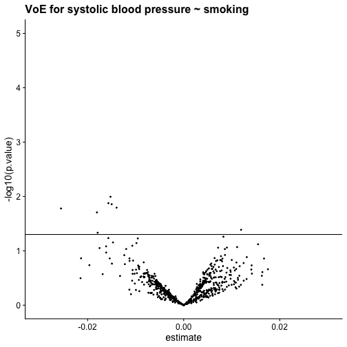

```r
ggplot(data=vibration_output[['data']] %>% filter(dependent_feature=='MSYS'),aes(x=estimate,y=-log10(p.value))) + geom_hline(yintercept = -log10(.05)) + geom_point(size=.5)+ xlim(-.03, 0.03) +ylim(0,5)+ggtitle('VoE for systolic blood pressure ~ smoking')
```

[figure not shown]

```r
ggplot(data=vibration_output[['data']] %>% filter(dependent_feature=='BMXBMI'),aes(x=estimate,y=-log10(p.value))) + geom_hline(yintercept = -log10(.05)) + geom_point(size=.5)+ xlim(-.03, 0.03) +ylim(0,5)+ggtitle('VoE for systolic blood pressure ~ BMI')
```

Looks like we have janus effects (positive and negative associations depending on modeling strategy) in both. Not only that, it looks like you can achieve nominal statistical significance depending on model specification in both cases.

To get an idea of what might be causing this, let's take a look at the confounder analysis.

```r
vibration_output[['confounder_analysis']]
```

```
## # A tibble: 340 x 8
##    effect group term            estimate std.error statistic     sdmin     sdmax
##    <chr>  <chr> <chr>              <dbl>     <dbl>     <dbl>     <dbl>     <dbl>
##  1 fixed  <NA>  (Intercept)    0.00479    0.000205    23.4    0.00459    5.00e-3
##  2 fixed  <NA>  RIDAGEYR      -0.000488   0.000472    -1.03  -0.000960  -1.57e-5
##  3 fixed  <NA>  male           0.000731   0.000584     1.25   0.000147   1.32e-3
##  4 fixed  <NA>  SES_LEVEL      0.000285   0.000609     0.468 -0.000324   8.94e-4
##  5 fixed  <NA>  education      0.000885   0.000614     1.44   0.000270   1.50e-3
##  6 fixed  <NA>  RIDRETH1       0.0000865  0.000518     0.167 -0.000431   6.04e-4
##  7 fixed  <NA>  BMXBMI        -0.00415    0.000625    -6.65  -0.00478   -3.53e-3
##  8 fixed  <NA>  any_cad       -0.000648   0.000541    -1.20  -0.00119   -1.07e-4
##  9 fixed  <NA>  any_family_c… -0.000271   0.000710    -0.382 -0.000981   4.39e-4
## 10 fixed  <NA>  any_ht        -0.000584   0.000553    -1.06  -0.00114   -3.10e-5
## # … with 330 more rows
```

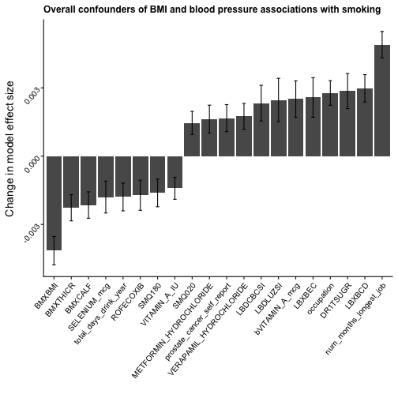

```r
confounder_analysis_significant = vibration_output[['confounder_analysis']] %>% filter(abs(statistic)>2.5) %>% arrange(desc(estimate)) %>% filter(term!='(Intercept)')

ggplot(confounder_analysis_significant,aes(x=reorder(term,estimate),y=estimate)) +geom_bar(stat='identity',position='dodge') + xlab('') + ylab('Change in model effect size')+ggtitle('Overall confounders of BMI and blood pressure associations with smoking ')+geom_errorbar(aes(ymin =sdmin,ymax=sdmax), width = 0.2, position = position_dodge(width = 0.9))+ theme(legend.position = 'bottom',plot.title = element_text(size=12))+theme(axis.text = element_text(size=10,angle=50,hjust=1))
```

The barplot above shows the top confounders of all associations. Something important to note – we fit a mixed effect model and aggregated across all assocaitions with BMI AND blood pressure. This means that the estimates reported in the barplot are for both dependent features. If you want to look at adjusters that are impactful for just one of the features, you'll need to run the pipeline with only one dependent variable or use the raw vibration output to run your own confounder analysis. For example, you could filter quantvoe_output[['vibration_output']]$data to where term == 'MSYS' then us the find_confounders_linear() function to look specifically at adjusters that impact blood pressure ~ smoking associations.

Finally, let's color the original VoE plots by some of the adjusters that were interesting to look at models with (or without) those adjusting variables.

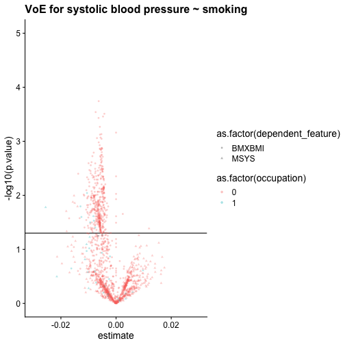

```r
ggplot(data=vibration_output[['data']],aes(shape=as.factor(dependent_feature),color=as.factor(occupation),x=estimate,y=-log10(p.value))) + geom_hline(yintercept = -log10(.05)) + geom_point(size=1,alpha=.3,)+ xlim(-.03, 0.03) +ylim(0,5)+ggtitle('VoE for systolic blood pressure ~ smoking')
```

While it's hard to see because this is a very small scale analysis, the models that adjusted for occupation (equal to 1 in the legend) tend to be on the left side of zero and their absolute value overall is larger than on average.